# Homework 1

#### Assumptions

The code below took too much time to run, the eval was set to FALSE to be able to post the report.

```r
probabilities <- predict(log_model_large, type = "response")
predicted.classes <- ifelse(probabilities > 0.5, "pos", "neg")
head(predicted.classes)

#Only numeric predictors
data <- trainSplit_large %>%
  dplyr::select_if(is.numeric)
predictors <- colnames(data)

# Bind the logit and tidying the data for plot
data <- data %>%
  mutate(logit = log(probabilities/(1-probabilities))) %>%
  gather(key = "predictors", value = "predictor.value", -logit)

#Scatter plot
ggplot(data, aes(logit, predictor.value))+
  geom_point(size = 0.5, alpha = 0.5) +
  geom_smooth(method = "loess") +
  theme_bw() +
  facet_wrap(~predictors, scales = "free_y")
```

Also, observations had to be independent of each other. As this is a randomly created dataset, we could assume that each sale record was independent.

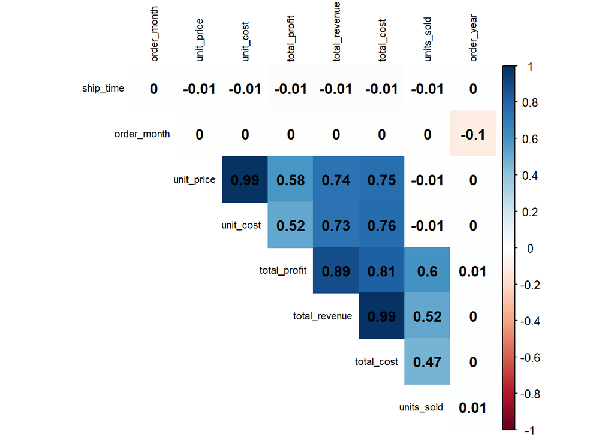

```r
rcore <- rcorr(as.matrix(trainSplit_large %>% dplyr::select(where(is.numeric))))
coeff <- rcore$r
corrplot(coeff, tl.cex = .7, tl.col="black", method = 'color', addCoef.col = "black",
         type="upper", order="hclust",
         diag=FALSE)
```

### 4.3 Cross-validation - 1000 Sales

The the k-fold cross-validation with Lasso regularization was used in order to improve feature selection for the Logistic regression model. The balanced data after SMOTE() was used with all the variables.

```r
# Train Lasso rmodel
set.seed(42)
lasso_model<- cv.glmnet(x_train,
                       y_train,
                       alpha = 1, #alpha=1 is lasso
                       family = "binomial",
                       link = "logit",
                       nfolds = 5,
                       type.measure = "class")
```

The `accuracy` of the Lasso model was 52% instead of the previous 56% in the Logistic model for 1000 sales. The AUC score of 0.46 didn’t suggest discriminative power. Based on the confusion matrix, the model performed worse in predicting critical priority as it was shown by the precision and recall values for class 1. `F1 score` was `0.27` (our model was 27% accurate in predicting positive cases), worse than in the previous models.

`AUC for the ROC curve` was `0.46`, it ranked a random positive example higher than a random negative example 46% of the time. The `residual deviance` of `1.42` showed that our model could predict the response variable much better than the model without Lasso.

The Akaike information criterion (`AIC`) was `-38` which was better comparing to all the previous models.

```r
glmnet_cv_aicc <- function(fit, lambda = 'lambda.min'){
  whlm <- which(fit$lambda == fit[[lambda]])
  with(fit$glmnet.fit,
       {
         tLL <- nulldev - nulldev * (1 - dev.ratio)[whlm]
         k <- df[whlm]
         n <- nobs
         return(list('AICc' = - tLL + 2 * k + 2 * k * (k + 1) / (n - k - 1),
                     'BIC' = log(n) * k - tLL))
       })
}
```

```r
# Predict the test data
lasso_prob <- predict(lasso_model, s = lasso_model$lambda.min, newx = x_test, type = "response")
lasso_pred <- ifelse(lasso_prob > 0.5, 1, 0)


# The features selected by Lasso
features_matrix <- as.matrix(coef(lasso_model, s = lasso_model$lambda.min))
selected_features <- rownames(features_matrix)[features_matrix != 0]

selected_features
```

```
##  [1] "(Intercept)"                        "regionAustralia and Oceania"
##  [3] "regionMiddle East and North Africa" "regionNorth America"
##  [5] "item_typeCereal"                    "item_typeClothes"
##  [7] "item_typeFruits"                    "item_typeMeat"
##  [9] "item_typeOffice Supplies"           "item_typeVegetables"
## [11] "units_sold"                         "ship_time"
## [13] "order_month"
```

```r
# Confusion matrix
conf_matrix_3 = confusionMatrix(factor(lasso_pred),factor(y_test), "1")


lasso.r1 <- assess.glmnet(lasso_model,
                                newx = x_test,
                                newy = y_test )
lasso.r2 <- glmnet_cv_aicc(lasso_model, 'lambda.min')

conf_matrix_3
```

```
## Confusion Matrix and Statistics
##
##           Reference
## Prediction  0  1
##          0 86 34
##          1 62 18
##
##                Accuracy : 0.52
##                  95% CI : (0.4484, 0.591)
##     No Information Rate : 0.74
##     P-Value [Acc > NIR] : 1.000000
##
##                   Kappa : -0.0619
##
##  Mcnemar's Test P-Value : 0.005857
##
##             Sensitivity : 0.3462
##             Specificity : 0.5811
##          Pos Pred Value : 0.2250
##          Neg Pred Value : 0.7167
##              Prevalence : 0.2600
##          Detection Rate : 0.0900
##    Detection Prevalence : 0.4000
##       Balanced Accuracy : 0.4636
##
##        'Positive' Class : 1
##
```

```r
results <- rbind(results,tibble(Model = "Model #3 - Lasso Model 1000 Sales", Accuracy=conf_matrix_3$overall[1],
                  "Classification error rate" = 1 - lasso.r1$auc[1],
                  F1 = conf_matrix_3$byClass[7],
                  Deviance=lasso.r1$deviance[[1]],
                  R2 = NA,
                  Sensitivity = conf_matrix_3$byClass["Sensitivity"],
                  Specificity = conf_matrix_3$byClass["Specificity"],
                  Precision =  conf_matrix_3$byClass["Precision"],
                  AIC= lasso.r2$AICc,
                  ROC = auc(roc(as.numeric(y_test), as.numeric(lasso_pred)))))
```

#### Assumptions

The observations had to be independent of each other. As this is a randomly created dataset, we could assume that each sale record was independent

Each fold in the k-fold cross-validation had to have approximately the same proportion of samples of each target class (stratified sampling).

### 4.4 Cross-validation - 50000 Sales

The steps to build the k-fold cross-validation with Lasso regularization were repeated for 50000 sales.

```r
# Train Lasso rmodel
set.seed(42)
lasso_model_large <- cv.glmnet(x_train_large,
                       y_train_large,
                       alpha = 1, #alpha=1 is lasso
                       family = "binomial",
                       link = "logit",
                       nfolds = 5,
                       type.measure = "class")
```

The `accuracy` of the Lasso model was 51%, almost the same as in the model without cross-validation. The AUC score of 0.5 didn’t suggest discriminative power. Based on the confusion matrix, the model the same as previous models with 49% sensitivity when predicting critical priority as it was shown by the precision and recall values for class 1.

`F1 score` was `0.33` (our model was 33% accurate in predicting positive cases), the same as for the model without Lasso. `AUC for the ROC curve` was `0.5`. The `residual deviance` of `1.38` showed that our model could predict the response variable much better than the model without Lasso.

The Lasso regularization showed that all region variables except for “Australia and Oceania”, sales_channel, units_sold, order_month were essential for the model.

The Akaike information criterion (`AIC`) was `-86`, it was better than in all the previous models.

```r
# Predict the test data
lasso_prob_large <- predict(lasso_model_large, s = lasso_model_large$lambda.min, newx = x_test_large, type = "response")
lasso_pred_large <- ifelse(lasso_prob_large > 0.5, 1, 0)


# The features selected by Lasso
features_matrix <- as.matrix(coef(lasso_model_large, s = lasso_model_large$lambda.min))
selected_features <- rownames(features_matrix)[features_matrix != 0]

selected_features
```

```
##  [1] "(Intercept)"
##  [2] "regionCentral America and the Caribbean"
##  [3] "regionEurope"
##  [4] "regionMiddle East and North Africa"
##  [5] "regionNorth America"
##  [6] "regionSub-Saharan Africa"
##  [7] "item_typeBeverages"
##  [8] "item_typeCereal"
##  [9] "item_typeClothes"
## [10] "item_typeCosmetics"
## [11] "item_typeFruits"
## [12] "item_typeHousehold"
## [13] "item_typeMeat"
## [14] "item_typeOffice Supplies"
## [15] "item_typePersonal Care"
## [16] "item_typeSnacks"
## [17] "item_typeVegetables"
## [18] "sales_channelOnline"
## [19] "units_sold"
## [20] "order_month"
```

```r
# Confusion matrix
conf_matrix_4 = confusionMatrix(factor(lasso_pred_large),factor(y_test_large), "1")


lasso.r1 <- assess.glmnet(lasso_model_large,
                                newx = x_test_large,
                                newy = y_test_large)
lasso.r2 <- glmnet_cv_aicc(lasso_model_large, 'lambda.min')


conf_matrix_4
```

```
## Confusion Matrix and Statistics
##
##           Reference
## Prediction    0    1
##          0 3882 1262
##          1 3629 1227
##
##                Accuracy : 0.5109
##                  95% CI : (0.5011, 0.5207)
##     No Information Rate : 0.7511
##     P-Value [Acc > NIR] : 1
##
##                   Kappa : 0.0074
##
##  Mcnemar's Test P-Value : <2e-16
##
##             Sensitivity : 0.4930
##             Specificity : 0.5168
##          Pos Pred Value : 0.2527
##          Neg Pred Value : 0.7547
##              Prevalence : 0.2489
##          Detection Rate : 0.1227
##    Detection Prevalence : 0.4856
##       Balanced Accuracy : 0.5049
##
##        'Positive' Class : 1
##
```

```r
results <- rbind(results,tibble(Model = "Model #4- Lasso Model 50000 Sales", Accuracy=conf_matrix_4$overall[1],
                  "Classification error rate" = 1 - lasso.r1$auc[1],
                  F1 = conf_matrix_4$byClass[7],
                  Deviance=lasso.r1$deviance[[1]],
                  R2 = NA,
                  Sensitivity = conf_matrix_4$byClass["Sensitivity"],
                  Specificity = conf_matrix_4$byClass["Specificity"],
                  Precision =  conf_matrix_4$byClass["Precision"],
                  AIC= lasso.r2$AICc,
                  ROC = auc(roc(as.numeric(y_test_large), as.numeric(lasso_pred_large)))))
```

#### Assumptions

The observations had to be independent of each other. As this is a randomly created dataset, we could assume that each sale record was independent

Each fold in the k-fold cross-validation had to have approximately the same proportion of samples of each target class (stratified sampling).

### 4.5 Random Forest - 1000 Sales

Next, we tried Random Forest Regression model for the small dataset. The original data without additional dummy variables with fixed imbalace in the target variables was used. The variables `total_profit`, `total_cost`, `total_revenue` were dropped as they were derived from other variables.

```r
set.seed(42)
# Build a Random Forest model
rf_model <- randomForest(critical_priority ~ . -total_profit -total_cost -total_revenue, data = split_rf, ntree = 100, importance = TRUE)
print(rf_model)
```

```
##
## Call:
##  randomForest(formula = critical_priority ~ . - total_profit -      total_cost - total_revenue, data = split_rf, ntree = 100,      importance = TRUE)
##                Type of random forest: classification
##                      Number of trees: 100
## No. of variables tried at each split: 3
##
##         OOB estimate of  error rate: 22.5%
## Confusion matrix:
##     0   1 class.error
## 0 340  80   0.1904762
## 1 109 311   0.2595238
```

The `accuracy` of the model was 57%. Comparing to th previous models, the Random forest model had a accuracy better but predicted worse critical priority as it was shown by the precision and recall values for class 1 (Sensitivity 40%). `F1 score` was `0.33` (our model was 33% accurate in predicting positive cases). `AUC for the ROC curve` was `0.52`.

```r
# Predict test data
rf_model_pred <- predict(rf_model, newdata = test_data_rf)

# Evaluate the model

conf_matrix_5 <- confusionMatrix(factor(rf_model_pred ), factor(test_data_rf$critical_priority), "1")


results <- rbind(results, tibble(Model = "Model #5 - Random Forest 1000 Sales", Accuracy=conf_matrix_5$overall[1],
                  "Classification error rate" = 1 - conf_matrix_5$overall[1],
                  F1 = conf_matrix_5$byClass[7],
                  Deviance= NA,
                  R2 = NA,
                  Sensitivity = conf_matrix_5$byClass["Sensitivity"],
                  Specificity = conf_matrix_5$byClass["Specificity"],
                  Precision = conf_matrix_5$byClass["Precision"],
                  AIC= NA,
                  ROC = auc(roc(test_data_rf$critical_priority, as.numeric(rf_model_pred)))))

conf_matrix_5
```

```
## Confusion Matrix and Statistics
##
##           Reference
## Prediction  0  1
##          0 94 31
##          1 54 21
##
##                Accuracy : 0.575
##                  95% CI : (0.5033, 0.6444)
##     No Information Rate : 0.74
##     P-Value [Acc > NIR] : 1.00000
##
##                   Kappa : 0.0341
##
##  Mcnemar's Test P-Value : 0.01702
##
##             Sensitivity : 0.4038
##             Specificity : 0.6351
##          Pos Pred Value : 0.2800
##          Neg Pred Value : 0.7520
##              Prevalence : 0.2600
##          Detection Rate : 0.1050
##    Detection Prevalence : 0.3750
##       Balanced Accuracy : 0.5195
##
##        'Positive' Class : 1
##
```

The plot below showed the feature importance, the Mean Decrease Accuracy showed how much the model accuracy decreased when we dropped that variable. Higher the value of mean decrease accuracy or mean decrease gini score, higher the importance of the variable in the model. Units sold, ship_time were the most important variables.

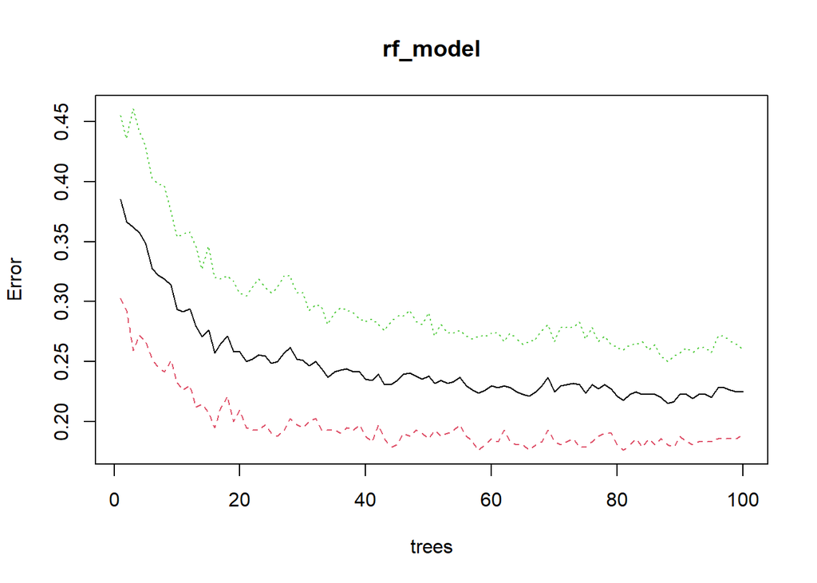

```r
plot(rf_model)
```

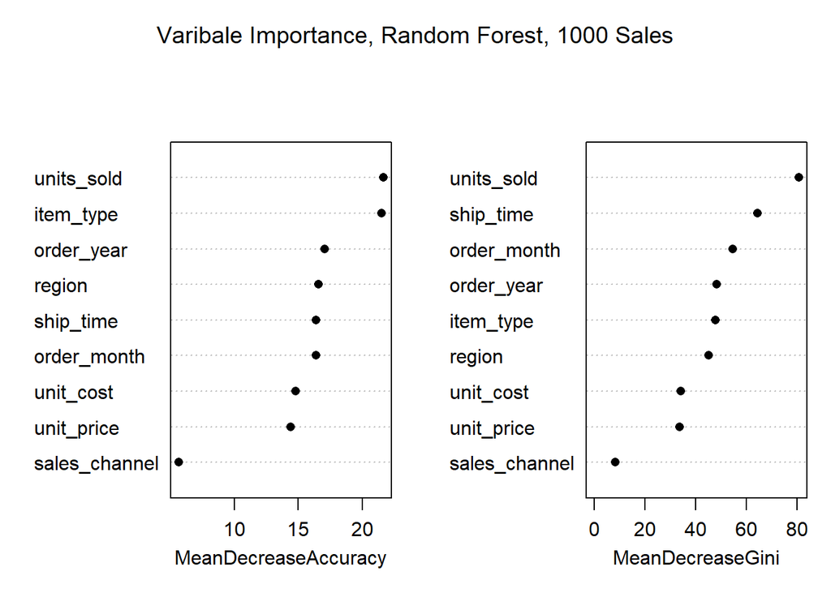

```r
varImpPlot(rf_model, main = "Varibale Importance, Random Forest, 1000 Sales" , pch=16)
```

#### Assumptions

Although Random Forest Regression didn’t have strict assumptions like linear models, there were several things to consider when building the model.

For example, there was no need for a data transformations or the need to follow a specific distribution as non-linear interactions can be captured without any explicit transformation.

The plot below depicted a single forest decision tree. Each node reflected a decision depending on the value of a feature. The decision tried to separate the data in such a way that the purity of the resulting child nodes was increased. Because the tree made binary choices, there were always two branches. The anticipated class was shown by the color of the leaf nodes, with darker colors signifying better predictions.

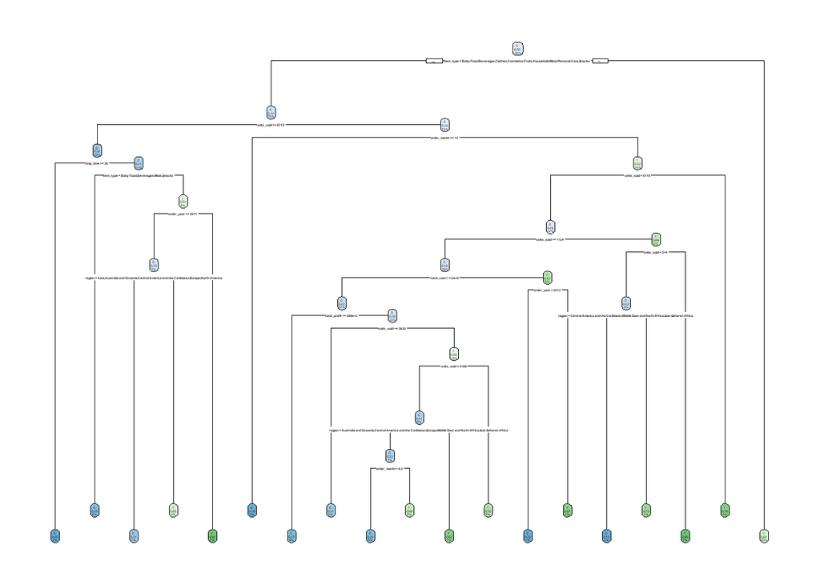

```r
# Build a single tree
single_tree <- rpart(critical_priority ~ . , data = split_rf, method = "class", control = rpart.control(cp = 0.01))

# Plot the tree
rpart.plot(single_tree)
```

### 4.6 Random Forest - 50000 Sales

As the last model, Random Forest Regression model for the large dataset.

Building the model for the larger dataset took significantly more time compared to the smaller dataset

```r
set.seed(42)
# Build a Random Forest model
rf_model_large <- randomForest(critical_priority ~ . -total_profit -total_cost -total_revenue, data = split_rf_large, ntree = 100, importance = TRUE)
print(rf_model_large)
```

```
##
## Call:
##  randomForest(formula = critical_priority ~ . - total_profit -      total_cost - total_revenue, data = split_rf_large, ntree = 100,      importance = TRUE)
##                Type of random forest: classification
##                      Number of trees: 100
## No. of variables tried at each split: 3
##
##         OOB estimate of  error rate: 24.88%
## Confusion matrix:
##       0     1 class.error
## 0 18776  1138  0.05714573
## 1  8771 11143  0.44044391
```

The `accuracy` of the model was 71%, better than all the previous models. The Random Forest model predicted certain crucial events, but with low precision and recall, the sensitivity was only 9%. `F1 score` was `0.14` (our model was 14% accurate in predicting positive cases). `AUC for the ROC curve` was `0.5`.

```r
# Predict test data
rf_model_pred_large <- predict(rf_model_large, newdata = test_data_large_rf)

# Evaluate the model

conf_matrix_6 <- confusionMatrix(factor(rf_model_pred_large), factor(test_data_large_rf$critical_priority), "1")


results <- rbind(results, tibble(Model = "Model #6 - Random Forest 50000 Sales", Accuracy=conf_matrix_6$overall[1],
                  "Classification error rate" = 1 - conf_matrix_6$overall[1],
                  F1 = conf_matrix_6$byClass[7],
                  Deviance= NA,
                  R2 = NA,
                  Sensitivity = conf_matrix_6$byClass["Sensitivity"],
                  Specificity = conf_matrix_6$byClass["Specificity"],
                  Precision =NA,
                  AIC= NA,
                  ROC = auc(roc(test_data_large_rf$critical_priority, as.numeric(rf_model_pred_large)))))

conf_matrix_6
```

```
## Confusion Matrix and Statistics
##
##           Reference
## Prediction    0    1
##          0 6844 2259
##          1  667  230
##
##                Accuracy : 0.7074
##                  95% CI : (0.6984, 0.7163)
##     No Information Rate : 0.7511
##     P-Value [Acc > NIR] : 1
##
##                   Kappa : 0.0046
##
##  Mcnemar's Test P-Value : <2e-16
##
##             Sensitivity : 0.09241
##             Specificity : 0.91120
##          Pos Pred Value : 0.25641
##          Neg Pred Value : 0.75184
##              Prevalence : 0.24890
##          Detection Rate : 0.02300
##    Detection Prevalence : 0.08970
##       Balanced Accuracy : 0.50180
##
##        'Positive' Class : 1
##
```

The plot below showed the feature importance., the Mean Decrease Accuracy showed how much the model accuracy decreased when we dropped that variable. Higher the value of mean decrease accuracy or mean decrease gini score, higher the importance of the variable in the model. Units sold was the most important variable.

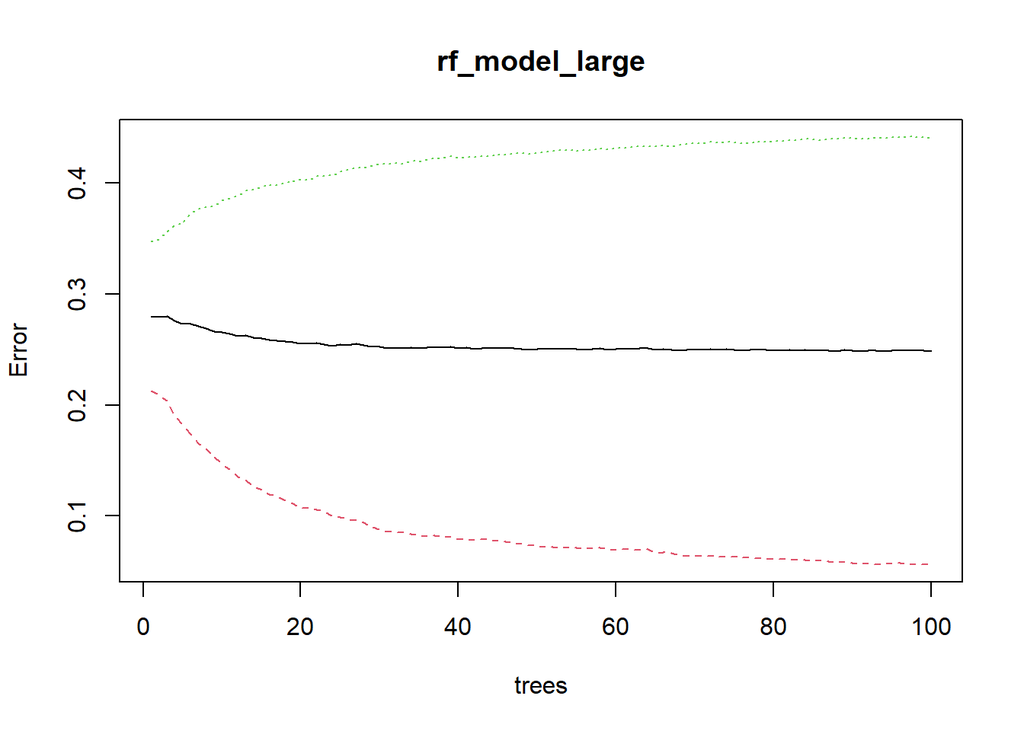

```r
plot(rf_model_large)
```

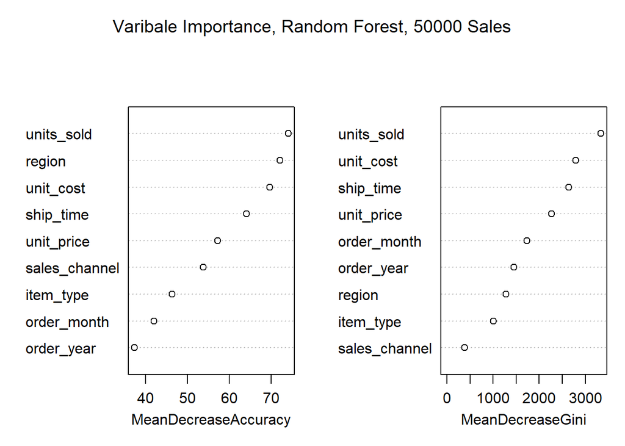

```r
varImpPlot(rf_model_large,  main = "Varibale Importance, Random Forest, 50000 Sales")
```

#### Assumptions

Although Random Forest Regression didn’t have strict assumptions like linear models, there were several things to consider when building the model.

For example, there was no need for a data transformations or the need to follow a specific distribution as non-linear interactions can be captured without any explicit transformation.

The plot below depicted a single forest decision tree. Each node reflects a decision depending on the value of a feature. The decision seeks to separate the data in such a way that the purity of the resulting child nodes is increased. Because the tree makes binary choices, there are always two branches. The anticipated class is shown by the color of the leaf nodes, with darker colors signifying better predictions.

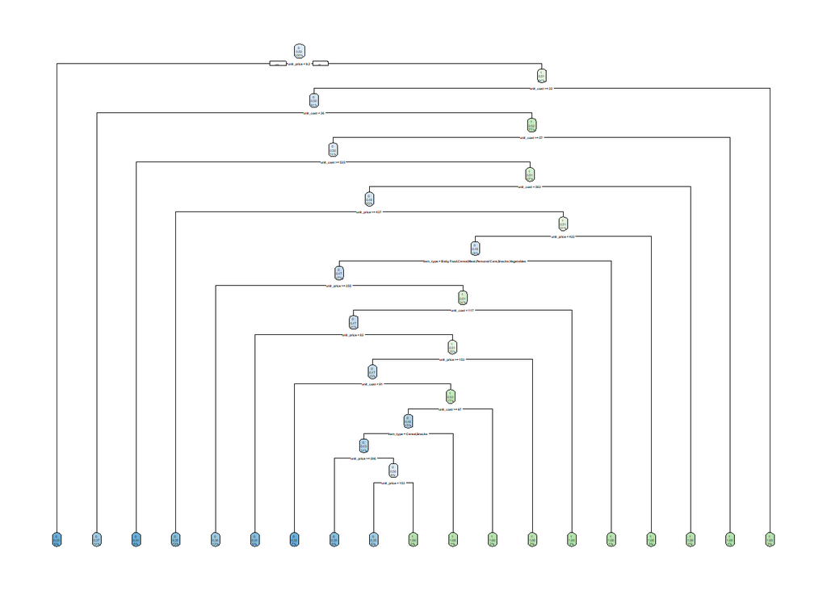

```r
# Build a single tree
single_tree <- rpart(critical_priority ~ . , data = split_rf_large, method = "class", control = rpart.control(cp = 0.01))

# Plot the tree
rpart.plot(single_tree)
```

## 5. Model selection

The accuracy of both Logistic Regression was almost the same for the “50000 Sales Records” and for the “1000 Sales Records” dataset. Though the Random Forest showed the accuracy greater for a larger data. The results improved a little for 50,000 sales with Lasso regularization and became worse for 1,000 sales. The Random forest worked better with 1,000 sales than with 50,000 sales.

Both algorithms struggled to reliably identify essential priorities, especially the Random Forest for 50000 sales. This could be due to the imbalance in the classes of the original data that we had to fix with SMOTE function, the necessity for more complex modeling methodologies (tuning hyperparameters, feature engineering, or using other modeling techniques), and the synthetic nature of the data.

Anyway, the Random Forest Regression would be a better choice with a real data. I would also choose this model for a small data, it worked with better results (accuracy, f1, sensitivity), it could predict some of the class 1 values. There were no requirements for preprocessing tasks such as scaling and normalization of each feature. For a large data. I would choose Logistic regression with Lasso regularization, it had similar results to other models but didn’t use all the features for training and had better AIC value. In reality, the larger datasets could give better results with a Random Forest as it was more representative, and models could be trained on more diverse data, making them more robust and less prone to overfitting though the time spent on the training and the requirements for computer’s capabilities would be higher.

```r
nice_table <- function(df, cap=NULL, cols=NULL, dig=3, fw=F){
  if (is.null(cols)) {c <- colnames(df)} else {c <- cols}
  table <- df %>%
    kable(caption=cap, col.names=c, digits=dig) %>%
    kable_styling(
      bootstrap_options = c("striped", "hover", "condensed"),
      html_font = 'monospace',
      full_width = fw)
  return(table)
}

results %>%
  nice_table(cap='Logistic Model Comparison') %>%
  scroll_box(width='100%')
```

Logistic Model Comparison

| Model | Accuracy | Classification error rate | F1 | Deviance | R2 | Sensitivity | Specificity | Precision | AIC | ROC |
| --- | --- | --- | --- | --- | --- | --- | --- | --- | --- | --- |
| Model #1 - Log Regression 1000 Sales | 0.565 | 0.435 | 0.374 | 1090.143 | 0.064 | 0.500 | 0.588 | 0.299 | 1140.143 | 0.5439189 |
| Model #2 - Log Regression 50000 Sales | 0.518 | 0.482 | 0.326 | 55042.615 | 0.003 | 0.470 | 0.534 | 0.250 | 55092.615 | 0.5016419 |
| Model #3 - Lasso Model 1000 Sales | 0.520 | 0.512 | 0.273 | 1.412 | NA | 0.346 | 0.581 | 0.225 | -38.200 | 0.4636175 |
| Model #4- Lasso Model 50000 Sales | 0.511 | 0.495 | 0.334 | 1.385 | NA | 0.493 | 0.517 | 0.253 | -86.875 | 0.5049055 |
| Model #5 - Random Forest 1000 Sales | 0.575 | 0.425 | 0.331 | NA | NA | 0.404 | 0.635 | 0.280 | NA | 0.5194906 |
| Model #6 - Random Forest 50000 Sales | 0.707 | 0.293 | 0.136 | NA | NA | 0.092 | 0.911 | NA | NA | 0.5018018 |

## 6. Conclusion

The datasets were generated with random logic and were not real sales data. Since the data was randomly generated, the patterns, connections, and distributions within the data were not indicative of real-world sales circumstances. As a result, any patterns or associations found by the models could be artifacts of the random data generating process but not real-world occurrences. Both, Logistic Regression and Random Forest, models struggled to identify significant priorities in both datasets. This difficulty was caused by the data’s inherent randomness, which lacks any underlying patterns that a model could leverage. Models trained on this data should not be used in real-world circumstances. The provided data was not adequate for true predictive modeling applications. The above work could be used for the preprocessing of sales data as it wouldn’t lead to costly mistakes on real data. In reality, if I had to make a business choice, I’d choose a model for the dataset with 50,000 sales as it had a larger sample size and was more likely to produce a more generic model. As mentioned above in the results and remembering the pros and cons of both algorithms, I would choose Random Forest Regression. But with these random data, the Random Forest model was a selection for 1,000 sales, Logistic regression with Lasso regularization for 50,000 sales.

As a result, the randomly generated data may be valuable for practice and testing, but it is critical to understand its limitations when evaluating results or contemplating its use.

## References

1. Verma, V. A. (2021). Downloads 18 – Sample CSV Files / Data Sets for Testing (till 5 Million Records) – Sales. Excel BI Analytics. https://excelbianalytics.com/wp/downloads-18-sample-csv-files-data-sets-for-testing-sales/
2. Nwanganga, F., & Chapple, M. (2020). *Practical Machine Learning in R.* https://doi.org/10.1002/9781119591542
3. Sheather, S. (2009). *A Modern Approach to Regression with R.* Springer Science & Business Media.
4. Faraway, J. J. (2016). *Extending the Linear Model with R: Generalized Linear, Mixed Effects and Nonparametric Regression Models.* CRC Press.
5. Verma, V. A. (2021b). Downloads 18 – Sample CSV Files / Data Sets for Testing (till 5 Million Records) – Sales. Excel BI Analytics. https://excelbianalytics.com/wp/downloads-18-sample-csv-files-data-sets-for-testing-sales/

## Appendix: Essay. Machine Learning models for Sales Data

The work below shows the stages from data preparation to model selection for the sales data.

The datasets with 1,000 sales and 50,000 sales, both with 17 predictor variables. There was no specific label for supervised learning. However, we created a new variable from `order_priority` called `critical_priority` to predict if the order was of a critical priority based on other features. Correlations between columns were thoroughly evaluated during the data processing phase. Notably, variables total_revenue, total_cost, and total_profit were derived from the variables unit_sold, unit_cost, unit_price.

The first critical step was data transformation. The target variable was the `critical_priority` column built from `Order Priority`. The critical orders were substituted with a `1` and all others with a `0`. The datasets were refined further for clarity and efficiency: columns were given standardized names (`Order.Priority` became `order_priority`), dates were formatted consistently, and extraneous columns such as `Country` and `Order ID` were removed. The `Order Date` and `Ship Date` columns were used to create new columns `order_year`, `order_month`, `ship_time` and were removed. Character columns were transformed into model-compatible dummy variables. As the target variable was binary, the following algorithms were considered. The following data preparation was based on this algorithm selection. The choice of the algorithms wasn’t affected by the size of the data, only by the nature of the target variable.

`Logistic regression`: simple, interpretable, and efficient, when the relationship independent variables and log chances are linear, it performs well, but may underperform when the data has complex, non-linear relationships.

`Random Forest`: can capture complicated, non-linear patterns in data, resistant to overfitting, can handle numerical as well as categorical data. But it is more difficult to interpret than simpler models, large datasets can be computationally expensive.

Logistic Regression was chosen because of its simplicity and applicability for binary classification. Random Forest was used to capture any non-linear relationships in the dataset. The size of the dataset also influenced the decision, as training a more sophisticated model on a larger dataset took substantially longer.

The datasets were divided into training (80%) and testing (20%) sets prior to modeling to ensure unbiased validation and a realistic evaluation of model performance on unknown data. The categorical variables were transformed to dummies for the Logistic models, the data without dummy variables was used for Random Forest. For the Lasso model, the training and testing data with all variables (no dummies) was transformed to matrix. All datasets had an imbalance in the target variable (~75% for class 0 and ~25% for class 1). With imbalanced data, most machine learning models predicted the majority class more efficiently than the minority class. To address this behavior, we utilized SMOTE() function the data in order to achieve higher accuracy rates between classes. The SMOTE function oversampled the minority class by using bootstrapping and k-nearest neighbor to synthetically create additional observations of that event. We tried to run models with imbalanced data and without.

`Logistic Regression - 1,000 Sales`. A logistic regression model was built for the smaller dataset of 1,000 sales. Due to their intricate relationship and probable multicollinearity, variables such as total_profit, total_cost, total_revenue were omitted, variables item_type_Vegetables, item_type_Snacks were removed as the model ran error when predicting the probabilities, the rank of the data matrix was at least equal to the number of parameters, it was not. The logistic regression model had a 71% accuracy. This model’s Akaike information criterion (AIC) was 926, indicating room for improvement. According to the confusion matrix, the model predicted important priority with 6% sensitivity, as evidenced by the precision and recall values for class 1. F1 score of 0.095 combined the precision and recall scores of a model (our model was 9.5% accurate in predicting positive cases and 90.5% inaccurate in predicting negative cases). According to feature importance, sales of fruits, and household items were more likely to be prioritized, whereas beverage sales were not.

`Logistic Regression - 50,000 Sales`. For the larger dataset, the same logistic regression model was applied with similar variable exclusions. The imbalance was fixed with the SMOTE() function (50% for class 1 and 50% for class 0 instead of 25%/75%), variables such as total_profit, total_cost, total_revenue were omitted. This model’s accuracy was 52%, lower than for the 1,000 sales. AIC was significantly at 55092.61. The feature importance showed units sold and item type Cosmetics had the largest positive influence, indicating that sales from this item were more likely to be prioritized. Item type clothes had the largest negative influence, indicating that sales from this category were less likely to be a major priority. The model predicted class 1 with sensitivity of 47%. This result was worse compared to the result for 1,000 sales. F1 score of 0.33 combined the precision and recall scores of a model (our model was 33% accurate in predicting positive cases and 67% inaccurate in predicting negative cases). AUC was the same, 0.5. The residual deviance of 55042.615 showed that our model couldn’t predict well the response variable.

`Random Forest - 1,000 & 50,000 Sales`. Following that, Random Forest, a well-known ensemble learning method, was used. The algorithm attained a 57% accuracy for the 1,000 sales dataset. The larger dataset of 50,000 sales, on the other hand, provided an accuracy of 71%. For both datasets, feature significance plots revealed that ‘units sold’ was the most influential variable. The precision and recall values for class 1 for the large dataset showed that the Random forest model predicted critical priority worse than the previous models (sensitivity 9%, f1 score 0.136). For 1,000 sales these metrics stayed almost the same but the accuracy increased (sensitivity 40%, f1 score 0.33). The AUC stayed almost the same for both models, 0.5 The Random forest worked better with 1,000 sales than with 50,000 sales.

The accuracy of both Logistic Regression was almost the same for the “50,000 Sales Records” and for the “1,000 Sales Records” dataset. However, the Random Forest showed the accuracy greater for a larger data. The results improved a little for 50,000 sales with Lasso regularization and became worse for 1,000 sales. The Random forest worked better with 1,000 sales than with 50,000 sales.

Both algorithms struggled to reliably identify essential priorities, especially the Random Forest for 50,000 sales. This could be due to the imbalance in the classes of the original data that we had to fix with SMOTE function, the necessity for more complex modeling methodologies (tuning hyperparameters, feature engineering, or using other modeling techniques), and the synthetic nature of the data.

Anyway, the Random Forest Regression would be a better choice with a real data. I would also choose this model for a small data, it worked with better results (accuracy, f1, sensitivity), it could predict some of the class 1 values. There were no requirements for preprocessing tasks such as scaling and normalization of each feature. For a large data, I would choose Logistic regression with Lasso regularization, it had similar results to other models but didn’t use all the features for training and had better AIC value. In reality, the larger datasets could give better results with a Random Forest as it was more representative, and models could be trained on more diverse data, making them more robust and less prone to overfitting.

The provided datasets were generated using random logic and were not genuine sales data. Since the data was randomly generated, the patterns, connections, and distributions within the data were not indicative of real-world sales circumstances. As a result, any patterns or associations found by the models could be artifacts of the random data generating process rather than real-world occurrences. Both our Logistic Regression and Random Forest models struggled to identify significant priorities in both datasets. This difficulty was caused by the data’s inherent randomness, which lacks any underlying patterns that a model could leverage. Models trained on this data should not be used in real-world circumstances. The provided data was not adequate for true predictive modeling applications. The above work could be used for the preprocessing of sales data as it wouldn’t lead to costly mistakes on real data. In reality, if I had to make a business choice, I’d choose a model for the dataset with 50,000 sales as it had a larger sample size and was more likely to produce a more generic model. As mentioned above in the results and remembering the pros and cons of both algorithms, I would choose Random Forest Regression. But with these random data, the Random Forest model was a selection for 1,000 sales, Logistic regression with Lasso regularization for 50,000 sales.

As a result, the randomly generated data might be valuable for practice and testing, but it is critical to understand its limitations when evaluating results or contemplating its use.